# Tea Plant Growth Simulator

Eric Scott

```r
library(tidyverse) #data wrangling and plotting
library(broom) #tidying up summaries of models
library(lme4) #mixed effect modeling
library(Hmisc) #has a nice Lag function
```

## 0.1 Simulate data that we will analyze

### 0.1.1 Simulation parameters that we will try to estimate

```r
N = 10 # number of plants
n.shoot = 7 #number of shoots per plant

# Mean daily growth rate of plants and sd
# there is variance from day to day
plant.r.mean = 1.05
plant.r.sd = 0.008

# Random effect for growth rate of plants
# Some plants just have better growth than others
random.effect.sd = 0.005
plant.id.effects = rnorm(N, 0, random.effect.sd) #The actual adjustment for each plant

# Shoots with larger stem diameters maybe grow faster
stem.dia.effect = 0.005
```

**note, I have not simulated any random effect of shoot within plant. I might need to do that**

### 0.1.2 Conduct the simulation

Although I was at the tea farm for about 50 days, I reset the shoot measurements everytime there was a harvest. Sometimes this was only ~15 days, sometimes it was more like 30 days.

```r
time = 15 # days

# Generate some random daily temperatures
daily.temperature = as.numeric(scale(diffinv(rnorm(time-1))))
```

**I’m not entirely sure what `diffinv()` is doing here. How can I make these temperatures realistic (in units of ºC)?**

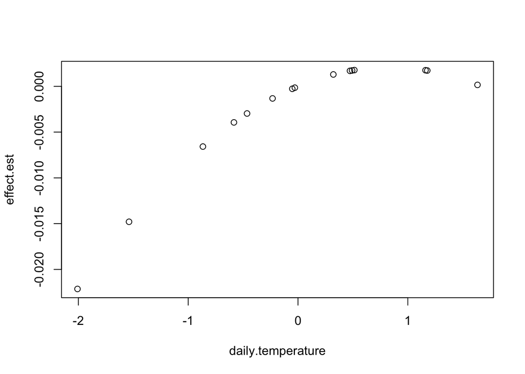

```r
#This is the effect of daily temperature on plant growth
temperature.effect.B1 = 0.005
temperature.effect.B2 = -0.003
effect.est = temperature.effect.B1*daily.temperature + temperature.effect.B2*daily.temperature^2
plot(effect.est~daily.temperature)
```

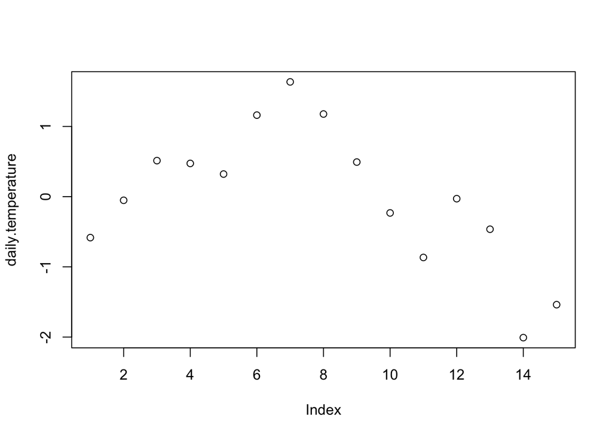

```r
plot(daily.temperature)
```

**Why are there two different temperature effect parameters? Is this just to get the shape right where high temperatures are detrimental to plant growth? I’m not sure this shape makes sense.**

I modified this to account for multiple shoots per plant. It generates a list of matrices, one matrix for each plant with 7 columns, one for each shoot, and rows for each day of growth.

```r
growth.matrixes <- replicate(N, matrix(NA, nrow = time, ncol = n.shoot), simplify = FALSE)
initial.shoot.sizes <- replicate(N, runif(n.shoot, 2, 5), simplify = FALSE)
stem.diameters <- replicate(N, rnorm(n.shoot, 0.25, 0.05), simplify = FALSE)

for(i in 1:N){
  growth.matrixes[[i]][1, ] <- initial.shoot.sizes[[i]]
}


#simulate growth

for(id in 1:N){
  for (i in 1:n.shoot){
    for (t in 2:time){
        temp.today = daily.temperature[t]

         #daily growth rate (with random effect for plant added in)
        r.today = rnorm(1,
                        plant.r.mean + plant.id.effects[id] + stem.dia.effect*stem.diameters[[id]][i],
                        plant.r.sd)

        #adjustment for weather effect today
        r.today = r.today + (temperature.effect.B1*temp.today + temperature.effect.B2*temp.today^2)

        # Size today depends on size yesterday multiplied by growth rate
        growth.matrixes[[id]][t,i] = growth.matrixes[[id]][t-1, i] * r.today
    }
  }
}
names(growth.matrixes) <- paste0("plant", 1:N)

#this combines matrixes into a data frame
(growth.data <- data.frame(lapply(data.frame(growth.matrixes), unlist)))
```

```
##    plant1.1 plant1.2 plant1.3 plant1.4 plant1.5 plant1.6 plant1.7 plant2.1
## 1  2.995957 3.389019 4.982622 3.639631 4.892362 3.098986 4.179398 3.140864
## 2  3.175467 3.540825 5.220697 3.830461 5.141928 3.259853 4.303140 3.313786
## 3  3.357841 3.688352 5.460278 4.046199 5.387853 3.424536 4.515700 3.499768
## 4  3.551679 3.817694 5.788590 4.229763 5.681407 3.560719 4.779827 3.632749
## 5  3.697866 3.968904 6.104474 4.426960 5.930392 3.728532 5.023740 3.766923
## 6  3.940469 4.174820 6.462075 4.635278 6.244164 3.914461 5.317465 3.942620
## 7  4.138295 4.292273 6.751104 4.839774 6.547111 4.061548 5.601077 4.143529
## 8  4.343528 4.473361 7.086913 5.089528 7.007445 4.247251 5.858984 4.329758
## 9  4.569017 4.672813 7.446619 5.280538 7.331469 4.494406 6.091963 4.546021
## 10 4.807856 4.911021 7.792808 5.539593 7.640813 4.695056 6.383863 4.792340
## 11 4.937875 5.114606 8.080465 5.796689 7.885021 4.914281 6.713717 4.981907
## 12 5.109976 5.360150 8.372810 6.147932 8.250484 5.200627 7.045023 5.190682
## 13 5.346786 5.519154 8.709215 6.440750 8.634378 5.493411 7.441234 5.366500
## 14 5.542547 5.626572 8.969692 6.614007 8.789096 5.555324 7.562501 5.537839
```

[output cut: 129 more lines]

### 0.1.3 Tidy data

Put the data into a format appropriate for modeling.

```r
growth.data.tidy <- growth.data %>%
  rownames_to_column(var = "Day") %>%                     #rownumbers represent days
  gather(-Day, key = plant.shoot, value = height) %>%     #similar to reshape
  separate(plant.shoot, into = c("plant", "shoot")) %>%   #E.g. splits plant1.1 into plant1 | 1
  mutate(Day = as.integer(Day))                           #by default, rownames_to_column uses character

# Add stem diameter to data frame
names(stem.diameters) <- paste0("plant", 1:N) #make a named list

growth.data.tidy <- bind_rows(stem.diameters) %>%   #collapse list into a dataframe
  add_column(shoot = as.character(1:n.shoot)) %>%   #add a column for shoot number to make merging easy
  gather(-shoot, key = plant, value = stem.dia) %>% #gather into long format
  full_join(growth.data.tidy)                       #join with data frame by "shoot" and "plant"
#check that it worked
# stem.diameters[[1]][1] == filter(growth.data.tidy, plant == "plant1" & shoot ==  1) %>% select(stem.dia)
growth.data.tidy
```

```
## # A tibble: 1,050 x 5
##    shoot plant  stem.dia   Day height
##    <chr> <chr>     <dbl> <int>  <dbl>
##  1 1     plant1    0.250     1   3.00
##  2 1     plant1    0.250     2   3.18
##  3 1     plant1    0.250     3   3.36
##  4 1     plant1    0.250     4   3.55
##  5 1     plant1    0.250     5   3.70
##  6 1     plant1    0.250     6   3.94
##  7 1     plant1    0.250     7   4.14
##  8 1     plant1    0.250     8   4.34
##  9 1     plant1    0.250     9   4.57
## 10 1     plant1    0.250    10   4.81
## # … with 1,040 more rows
```

### 0.1.4 Plot growth trajectories

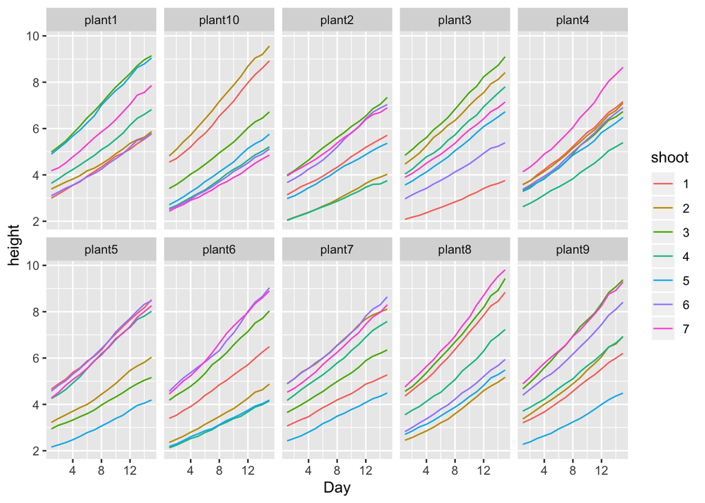

```r
ggplot(growth.data.tidy) +
  geom_line(aes(x = Day, y = height, color = shoot)) +
  facet_wrap("plant", ncol = 5)
```

These look a lot less noisy and variable than my actual data. In the real data there is a lot more measurement error (lines more squiggly) as well as maybe a little more variation between shoots and plants. Maybe I can adjust some parameters to make this more realistic.

## 0.2 Analyze the simulated data

Raw data is size of each shoot of each plant on each day of season. We want to calculate daily growth rates for each plant to analyze with `lmer()`.

### 0.2.1 Calculate daily growth rates for each plant

```r
#first, figure out how to lag heights to get height_t+1
#stats::lag(growth.data.tidy$height, k = -1) #<- this one doesn't seem to work right
#Hmisc::Lag(growth.data.tidy$height, shift = -1) #<-this one works like I'd expect

#r = height_t+1/height_t
growth.rates.data <- growth.data.tidy %>%
  group_by(plant, shoot) %>%
  mutate(height_t.1 = Lag(height, shift = -1),
         r = Lag(height, shift = -1)/height,
         temp = daily.temperature)            #might as well add the temperature data while I'm at it

growth.rates.data
```

```
## # A tibble: 1,050 x 8
## # Groups:   plant, shoot [70]
##    shoot plant  stem.dia   Day height height_t.1     r    temp
##    <chr> <chr>     <dbl> <int>  <dbl>      <dbl> <dbl>   <dbl>
##  1 1     plant1    0.250     1   3.00       3.18  1.06 -0.584
##  2 1     plant1    0.250     2   3.18       3.36  1.06 -0.0520
##  3 1     plant1    0.250     3   3.36       3.55  1.06  0.513
##  4 1     plant1    0.250     4   3.55       3.70  1.04  0.473
##  5 1     plant1    0.250     5   3.70       3.94  1.07  0.322
##  6 1     plant1    0.250     6   3.94       4.14  1.05  1.16
##  7 1     plant1    0.250     7   4.14       4.34  1.05  1.63
##  8 1     plant1    0.250     8   4.34       4.57  1.05  1.18
##  9 1     plant1    0.250     9   4.57       4.81  1.05  0.493
## 10 1     plant1    0.250    10   4.81       4.94  1.03 -0.232
## # … with 1,040 more rows
```

```r
# saveRDS(growth.rates.data, "growth rates data.rds")
```

### 0.2.2 Plot the daily growth rates for each plant

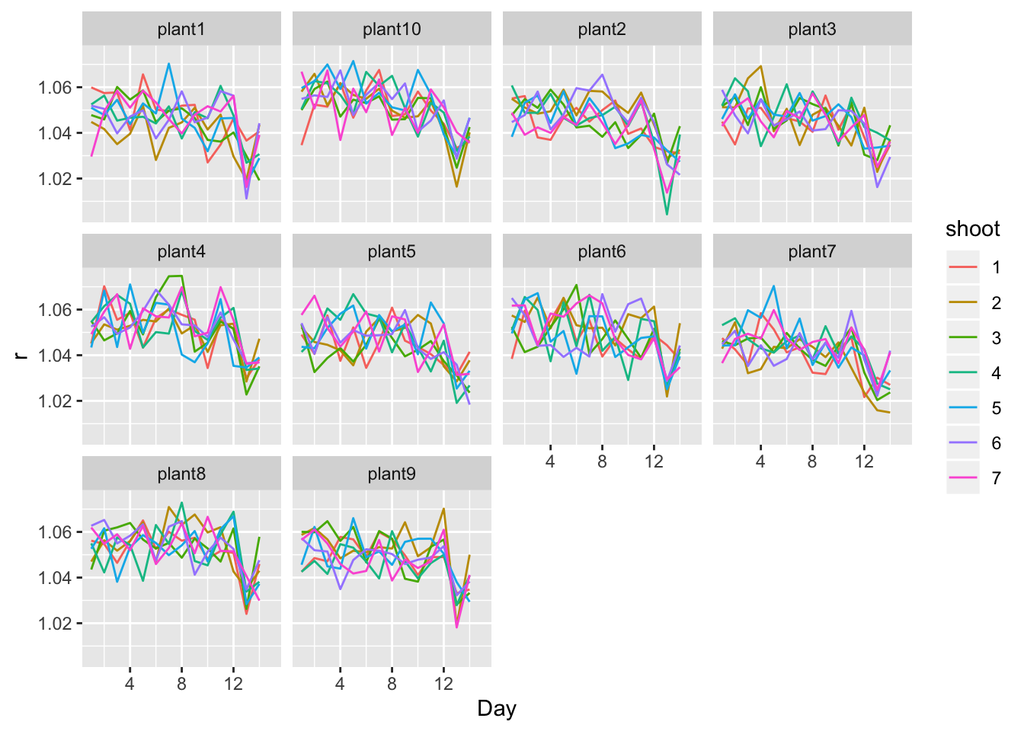

```r
ggplot(growth.rates.data) +
  geom_line(aes(x = Day, y = r, color = shoot)) +
  facet_wrap("plant")
```

looks more noisy than the height data, but not sure how this compares to real data.

### 0.2.3 plot growth vs. temp

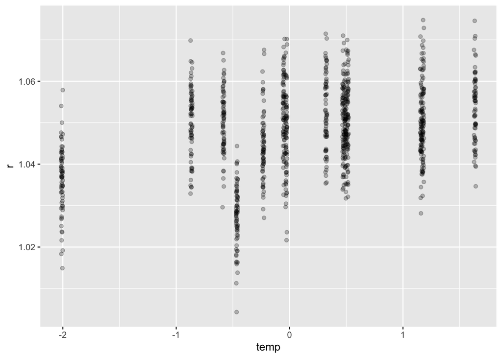

```r
ggplot(growth.rates.data) +
  geom_jitter(aes(x = temp, y = r), alpha = 0.25, width = 0.008) +
  theme(legend.position="none")
```

## 0.3 The actual statistical analyses

### 0.3.1 Basic linear model

(no random effects or temperature effects)

```r
plant.lm1 = lm(r ~ 1, data = growth.rates.data)
tidy(plant.lm1) %>%
  mutate(true.param = plant.r.mean) %>%
  select(term, estimate, std.error, true.param)
```

```
## # A tibble: 1 x 4
##   term        estimate std.error true.param
##   <chr>          <dbl>     <dbl>      <dbl>
## 1 (Intercept)     1.05  0.000349       1.05
```

Estimated daily growth rate is 1.0477 This is actually pretty close to our true parameter, 1.05!

### 0.3.2 Add temperature effects

```r
plant.lm2 = lm(r ~ temp + I(temp^2), data = growth.rates.data)
options(scipen = 5) #tunes cut-off for scientific notation for prettier output

tidy(plant.lm2) %>%                              # turns output of model into dataframe.  Alternative to print()
  mutate(true.param = c(plant.r.mean,            #add a column with the input parameters
                        temperature.effect.B1,
                        temperature.effect.B2)) %>%
  select(term, estimate, std.error, true.param)
```

```
## # A tibble: 3 x 4
##   term         estimate std.error true.param
##   <chr>           <dbl>     <dbl>      <dbl>
## 1 (Intercept)  1.05      0.000410      1.05
## 2 temp         0.00420   0.000365      0.005
## 3 I(temp^2)   -0.000583  0.000288     -0.003
```

### 0.3.3 Add stem diameter covariate

```r
plant.lm3 = lm(r ~ temp*stem.dia + I(temp^2)*stem.dia, data = growth.rates.data)
options(scipen = 5)

tidy(plant.lm3) %>%
  mutate(true.param = c(plant.r.mean,
                        temperature.effect.B1,
                        stem.dia.effect,
                        temperature.effect.B2,
                        NA,
                        NA)) %>%
  select(term, estimate, std.error, true.param)
```

```
## # A tibble: 6 x 4
##   term                estimate std.error true.param
##   <chr>                  <dbl>     <dbl>      <dbl>
## 1 (Intercept)         1.04       0.00228      1.05
## 2 temp                0.00476    0.00203      0.005
## 3 stem.dia            0.0172     0.00904      0.005
## 4 I(temp^2)           0.000894   0.00160     -0.003
## 5 temp:stem.dia      -0.00223    0.00804     NA
## 6 stem.dia:I(temp^2) -0.00595    0.00635     NA
```

### 0.3.4 Random plant ID effects and fixed temperature effects

```r
plant.lmer = lmer(r ~ temp + I(temp^2) + (1|plant), data = growth.rates.data)
options(scipen = 6)

tidy(plant.lmer) %>%
  mutate(true.param = c(plant.r.mean,
                        temperature.effect.B1,
                        temperature.effect.B2,
                        plant.r.sd,
                        NA)) %>%
  select(term, estimate, std.error, true.param, group)
```

```
## # A tibble: 5 x 5
##   term                     estimate std.error true.param group
##   <chr>                       <dbl>     <dbl>      <dbl> <chr>
## 1 (Intercept)              1.05      0.00120       1.05  fixed
## 2 temp                     0.00420   0.000344      0.005 fixed
## 3 I(temp^2)               -0.000583  0.000272     -0.003 fixed
## 4 sd_(Intercept).plant     0.00360  NA             0.008 plant
## 5 sd_Observation.Residual  0.00961  NA            NA     Residual
```

### 0.3.5 Add stem diameter to lmer model

```r
plant.lmer2 = lmer(r ~ temp + I(temp^2) + stem.dia + (1|plant), data = growth.rates.data)
options(scipen = 6)

tidy(plant.lmer2) %>%
  mutate(true.param = c(plant.r.mean,
                        temperature.effect.B1,
                        temperature.effect.B2,
                        stem.dia.effect,
                        plant.r.sd,
                        NA)) %>%
  select(term, estimate, std.error, true.param, group)
```

```
## # A tibble: 6 x 5
##   term                     estimate std.error true.param group
##   <chr>                       <dbl>     <dbl>      <dbl> <chr>
## 1 (Intercept)              1.05      0.00215       1.05  fixed
## 2 temp                     0.00420   0.000344      0.005 fixed
## 3 I(temp^2)               -0.000583  0.000272     -0.003 fixed
## 4 stem.dia                 0.00960   0.00720       0.005 fixed
## 5 sd_(Intercept).plant     0.00359  NA             0.008 plant
## 6 sd_Observation.Residual  0.00961  NA            NA     Residual
```